# Project 1 GR5243 Data blog

Binglun Zhao bz2342

# Happy Moment Data blog

**From more than 100,000 happy moment messages from over 10,000 respomndents, the first thing I want to figure out is “What the hottest topics are they concerned?”. In order to find the mixture of words that is associated with each topic, I ran Latent Dirichlet allocation by using Gibbs sampling to generate 10 different topics.I chose couple of the figures to show the topics I finalized.**

```r
packages.used=c("rvest", "tibble", "qdap",
                "sentimentr", "gplots", "dplyr",
                "tm", "syuzhet", "factoextra",
                "beeswarm", "scales", "RColorBrewer",
                "RANN", "tm", "topicmodels")
# check packages that need to be installed.
packages.needed=setdiff(packages.used,
                        intersect(installed.packages()[,1],
                                  packages.used))
# install additional packages
if(length(packages.needed)>0){
  install.packages(packages.needed, dependencies = TRUE)
}
# load packages
library("rvest")
library("tibble")
# You may need to run
# sudo ln -f -s $(/usr/libexec/java_home)/jre/lib/server/libjvm.dylib /usr/local/lib
# in order to load qdap
library("qdap")
library("sentimentr")
library("gplots")
library("dplyr")
library("tm")
library("syuzhet")
library("factoextra")
library("beeswarm")
library("scales")
library("RColorBrewer")
library("RANN")
library("tm")
library("topicmodels")
source("../lib/plotstacked.R")
#source("../lib/speechFuncs.R")
```

```r
happy.moment=read.csv("../output/processed_moments.csv", stringsAsFactors = FALSE)
demographic=read.csv("../data/demographic.csv")
```

```r
Happy.text <- happy.moment$text
#Create document-term matrix
docs <- Corpus(VectorSource(Happy.text))
dtm <- DocumentTermMatrix(docs)
rownames(dtm) <- paste(happy.moment$reflection_period, happy.moment$wid,
                       happy.moment$predicted_category, happy.moment$hmid, sep="_")
rowTotals <- apply(dtm , 1, sum)
dtm  <- dtm[rowTotals> 0, ]
happy.moment=happy.moment[rowTotals>0, ]
```

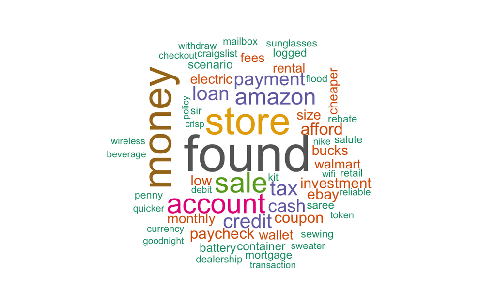

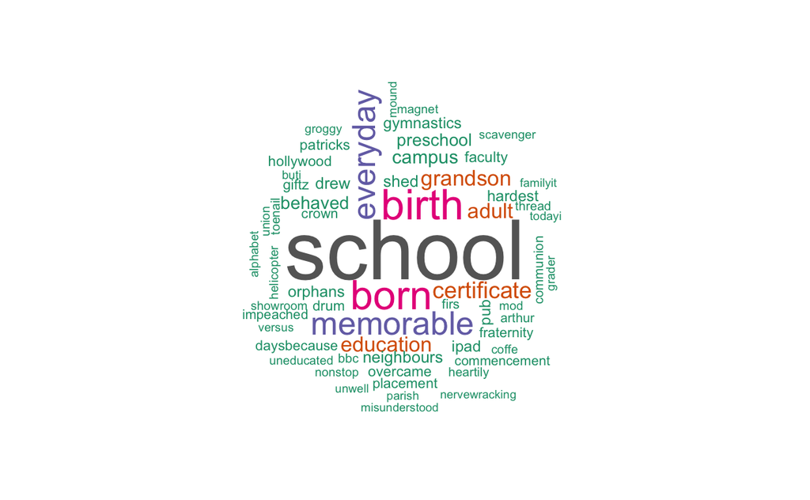

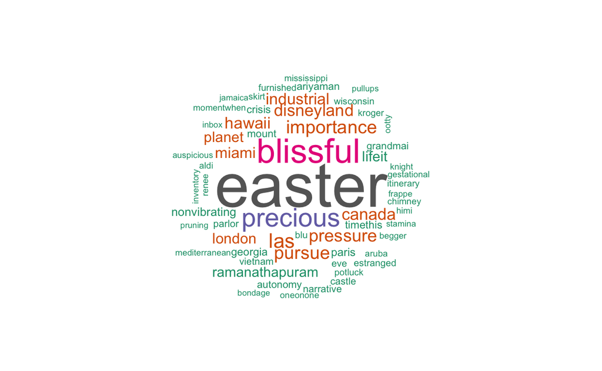

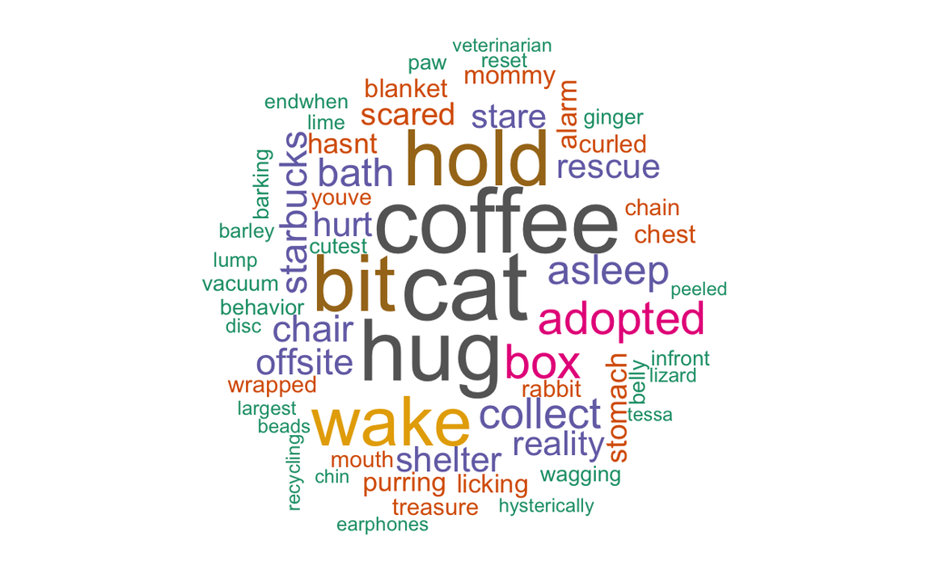

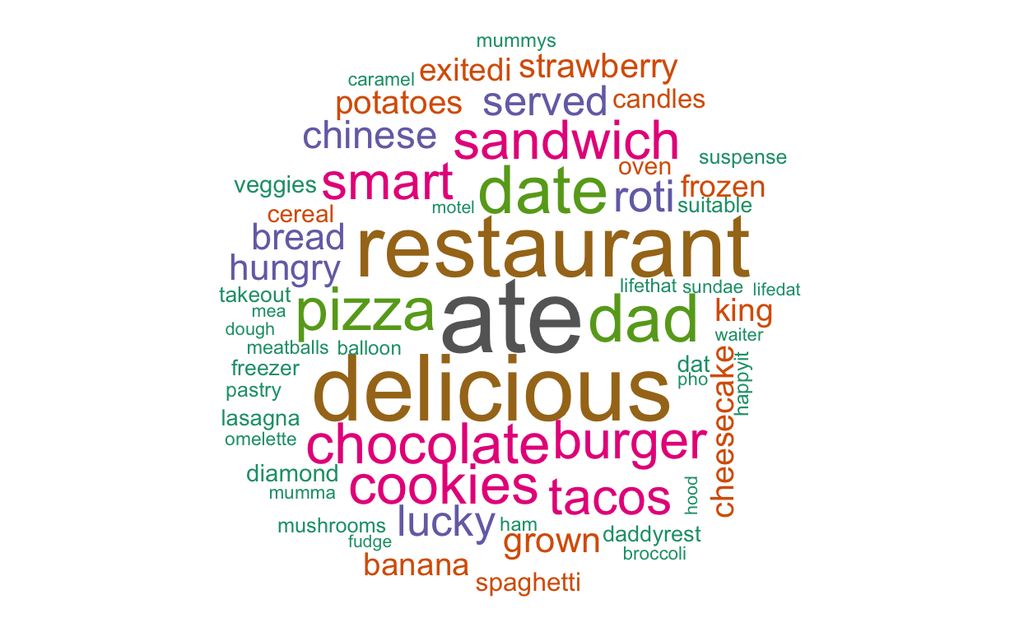

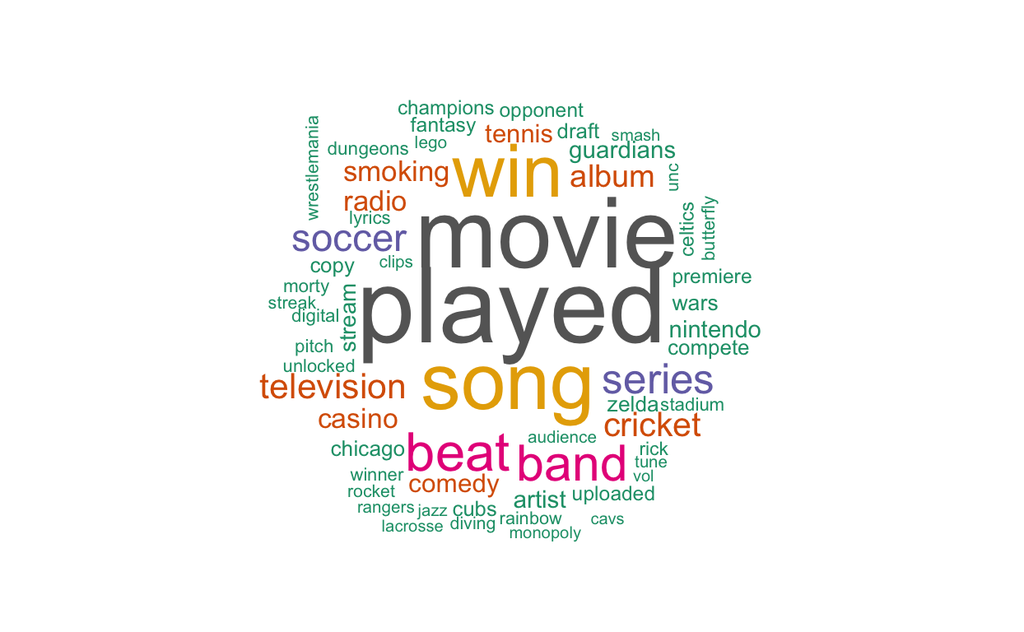

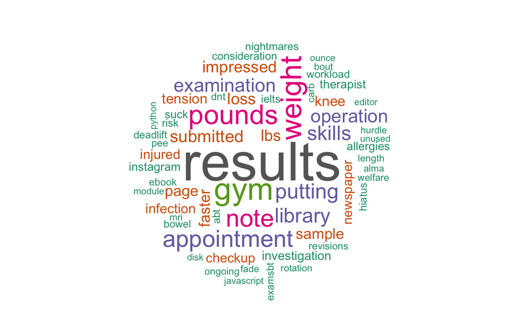

[figure not shown]